# DS3 Data Memo

Avriana Allen | 4.24.2020

## The Data

There are several accompanying [data dictionaries](https://collegescorecard.ed.gov/data/documentation/) which are downloadable as a single [`xlsx` file](https://collegescorecard.ed.gov/assets/CollegeScorecardDataDictionary.xlsx).

The Institutions data set has 1,982 variables. It is likely that many of these categories may be collapsed into larger categories, or ignored for the sake of simplicity.

Variables and Descriptions

| variable_name | name_of_data_element |
| --- | --- |
| UNITID | Unit ID for institution |
| OPEID | 8-digit OPE ID for institution |
| OPEID6 | 6-digit OPE ID for institution |
| INSTNM | Institution name |
| CITY | City |
| STABBR | State postcode |
| ZIP | ZIP code |
| ACCREDAGENCY | Accreditor for institution |
| INSTURL | URL for institution’s homepage |
| NPCURL | URL for institution’s net price calculator |
| SCH_DEG | Predominant degree awarded (recoded 0s and 4s) |
| HCM2 | Schools that are on Heightened Cash Monitoring 2 by the Department of Education |
| MAIN | Flag for main campus |
| NUMBRANCH | Number of branch campuses |
| PREDDEG | Predominant undergraduate degree awarded 0 Not classified 1 Predominantly certificate-degree granting 2 Predominantly associate’s-degree granting 3 Predominantly bachelor’s-degree granting 4 Entirely … |
| HIGHDEG | Highest degree awarded 0 Non-degree-granting 1 Certificate degree 2 Associate degree 3 Bachelor’s degree 4 Graduate degree |
| CONTROL | Control of institution |
| ST_FIPS | FIPS code for state |
| REGION | Region (IPEDS) |
| LOCALE | Locale of institution |
| LOCALE2 | Degree of urbanization of institution |
| LATITUDE | Latitude |
| LONGITUDE | Longitude |
| CCBASIC | Carnegie Classification – basic |
| CCUGPROF | Carnegie Classification – undergraduate profile |
| CCSIZSET | Carnegie Classification – size and setting |
| HBCU | Flag for Historically Black College and University |
| PBI | Flag for predominantly black institution |
| ANNHI | Flag for Alaska Native Native Hawaiian serving institution |
| TRIBAL | Flag for tribal college and university |

[output cut: 1952 more lines]

## Data Questions

After looking at the variables available, it would interesting to predict a few different outcomes. Student loan repayment, percentage of specific degrees or mean earnings of students would all be interesting to consider.

However, each of those categories is split into smaller groups such as family income or number of years since enrollment. To work with any of them, I will need to create specific response variable, which depending on the question I choose to answer, may be several categories put together.

This is a survey of more or less all of the colleges in the U.S. which means that it is a population and not a sample. Many of results however, are likely samples. We may be able to make inferences about the population given our ability to randomly sample from it.

If this is possible, it would be interesting to see what traits can be used to predict student debt or earnings as well as seeing what characteristics the colleges with the best and worst earnings have in terms of admission, diversity, etc.

Random Forests or Boosted models might be good for this given the number of categorical variables available. Although other models have not yet been covered, they may also be useful, especially if there are not linear relationships between the response variables and the predictors.

## Data Issues

This data set will be a challenge, not only because of the number of variables or decisions that will need to be made concerning which ones to use, but also because of missing values. In the `csv` form they are listed as `NULL` which does not carry over well into R.

Another issue to deal with will be how to collapse the variables. It is likely that a lot of regex work with the appropriate data dictionary will be done.

## Exploratory Graphs and Tables

#### Informative Admissions Table

A table of information about each institution, including its name, state and admission rate.

Institution Information

| instnm | stabbr | adm_rate |
| --- | --- | --- |
| Alabama A & M University | AL | 0.8986 |
| University of Alabama at Birmingham | AL | 0.9211 |
| Amridge University | AL | NULL |
| University of Alabama in Huntsville | AL | 0.8087 |
| Alabama State University | AL | 0.9774 |
| The University of Alabama | AL | 0.5906 |
| Central Alabama Community College | AL | NULL |
| Athens State University | AL | NULL |
| Auburn University at Montgomery | AL | 0.9281 |
| Auburn University | AL | 0.7543 |
| Birmingham Southern College | AL | 0.5666 |
| Chattahoochee Valley Community College | AL | NULL |
| South University-Montgomery | AL | NULL |
| Enterprise State Community College | AL | NULL |
| Coastal Alabama Community College | AL | NULL |
| Faulkner University | AL | 0.5227 |
| Gadsden State Community College | AL | NULL |
| New Beginning College of Cosmetology | AL | NULL |
| George C Wallace Community College-Dothan | AL | NULL |
| George C Wallace State Community College-Hanceville | AL | NULL |
| George C Wallace State Community College-Selma | AL | NULL |
| Herzing University-Birmingham | AL | 0.95 |
| Huntingdon College | AL | 0.5841 |
| Heritage Christian University | AL | NULL |
| J. F. Drake State Community and Technical College | AL | NULL |
| J F Ingram State Technical College | AL | NULL |
| Jacksonville State University | AL | 0.543 |
| Jefferson State Community College | AL | NULL |
| John C Calhoun State Community College | AL | NULL |
| Judson College | AL | 0.482 |

[output cut: 6776 more lines]

#### Two graphs on Engineering Degrees

Key Terms:

- **Admission rate**
- **Engineering**: Percentage of degrees awarded in Engineering.

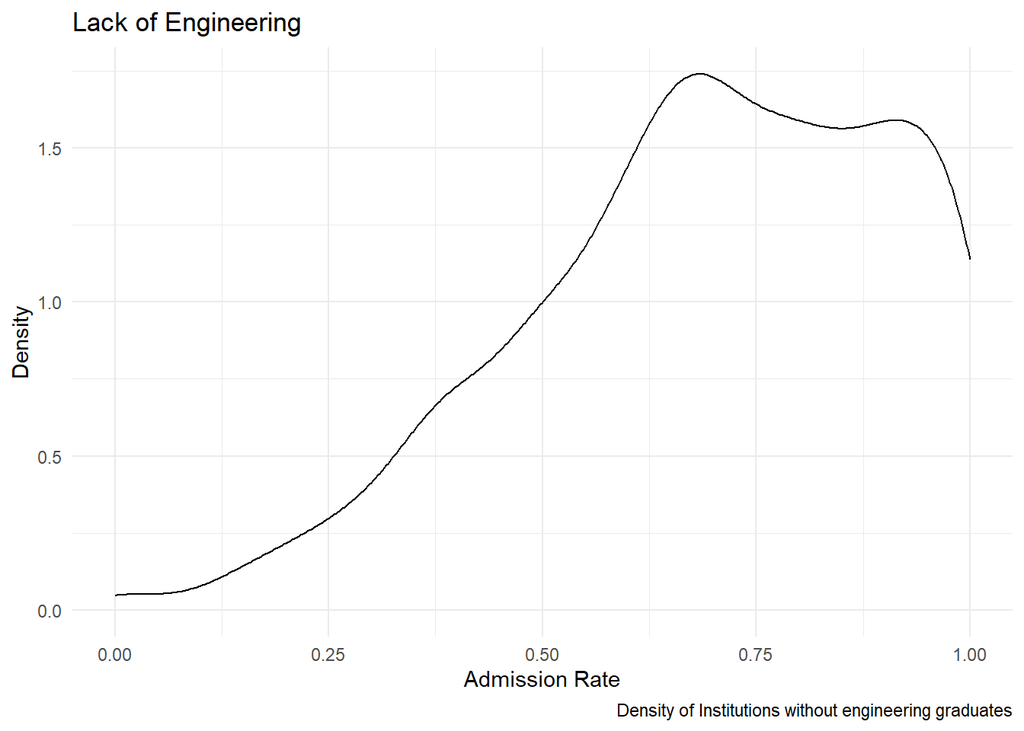

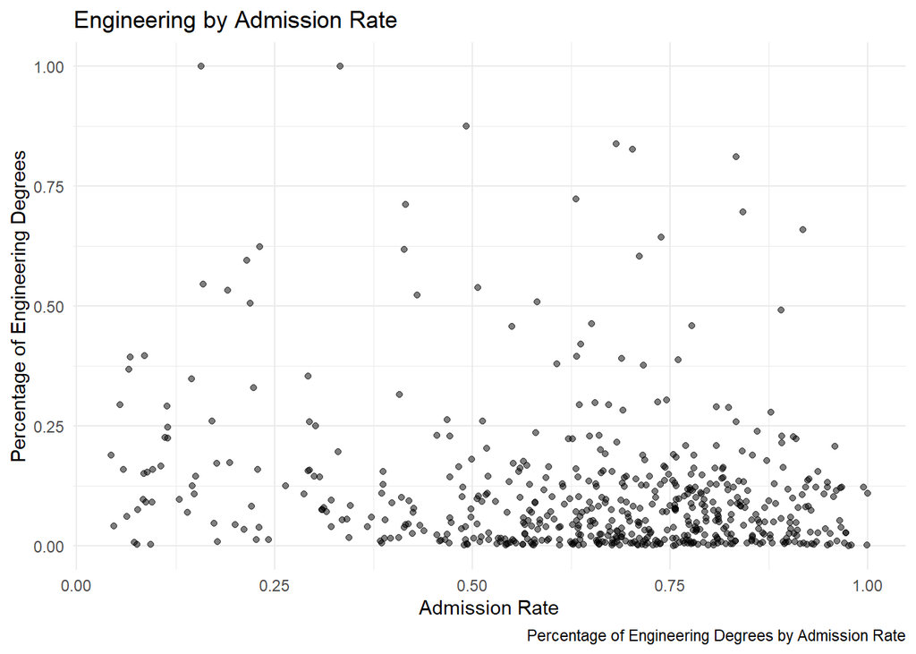

#### Student Earnings

A quick graph on the earnings of students after they have been out of college for 10 Years.

Key Terms

- **Admission rate**
- **Median**: Median earnings of students working and not enrolled 10 years after entry
- **Mean**: Mean earnings of students working and not enrolled 10 years after entry

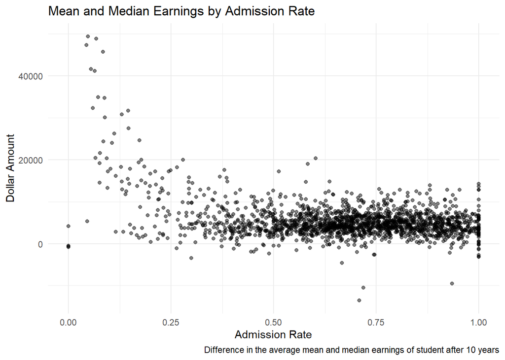